# QK Box 16.3

Parkinson et al. (2020) set tested experimentally the effect of artificial light at night (ALAN) and fish presence on abundances of terrestrial and aquatic invertebrates in the littoral zone of a small lake. They established 20 mesocosms (1 m2 plastic mesh walls and bottom submerged with part of the walls above the water surface) with ten provided with ALAN (solar lights in each corner) and ten controls. Half the mesocosms in each group had fish added, but there were no effects of fish on any variables, so Parkinson et al. ignored fish in the subsequent analyses. After about six weeks, a single pan trap was placed in each mesocosm overnight, and invertebrates were identified to family and counted. We will use these data to do an ordination of mesocosms based on invertebrate family abundances and then fit models to examine differences between the two treatment groups (ALAN vs. no-ALAN).

The paper is [here](https://doi.org/10.1371/journal.pone.0240138)

Parkinson, E., Lawson, J. & Tiegs, S. D. (2020). Artificial light at night at the terrestrial-aquatic interface: Effects on predators and fluxes of insect prey. *PLoS One*, 15, e0240138.

### Preliminaries

```r
# Load standard set of graphics packages and other libraries
source("../R/appearance.R")
source("../R/libraries.R")
```

Load packages specific to this example: vegan,mvabund

```r
library(vegan)
library(mvabund)
```

Read in data file (park2020.csv) and remove labels

```r
park <- read.csv("../data/park2020.csv")
park1 <- park[,-(1:3)]
```

### MDS on invert abundances

```r
park1.bc <- vegdist(park1,'bray')
park1.mds <- metaMDS(park1.bc,k=2,autotransform=FALSE)
```

```
*** Best solution repeated 11 times
```

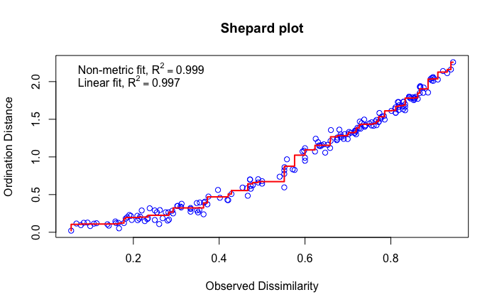

```r
stressplot(park1.mds, main="Shepard plot")
```

```r
park1.mds
```

```
Call:
metaMDS(comm = park1.bc, k = 2, autotransform = FALSE)

global Multidimensional Scaling using monoMDS

Data:     park1.bc
Distance: bray

Dimensions: 2
Stress:     0.0314779
Stress type 1, weak ties
Best solution was repeated 11 times in 20 tries
The best solution was from try 0 (metric scaling or null solution)
Scaling: centring, PC rotation, halfchange scaling
Species: scores missing
```

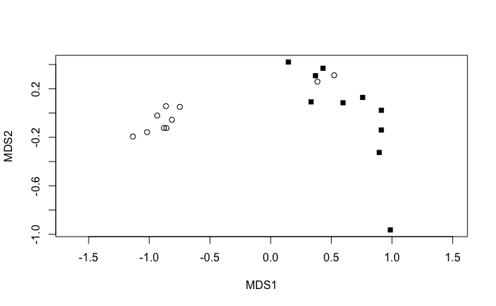

```r
ordiplot(park1.mds$points,display="sites",type="n")
points(park1.mds$points,pch=as.numeric(park$symb))
```

With standardisation (wisconsin)

```r
park1s <- wisconsin(park1)
park1s.bc <- vegdist(park1s,'bray')
park1s.mds <- metaMDS(park1s.bc,k=3,autotransform=FALSE,try=40,trymax=80,maxit=200)
```

```
*** Best solution repeated 5 times
```

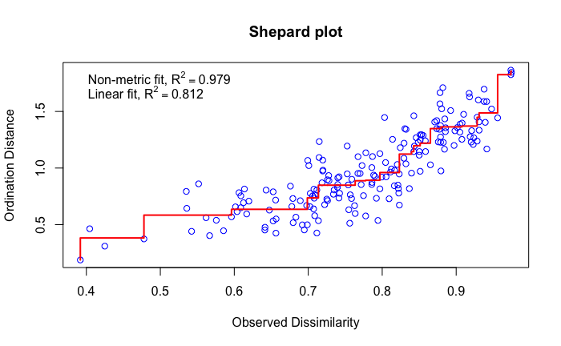

```r
stressplot(park1s.mds, main="Shepard plot")
```

```r
park1s.mds
```

```
Call:
metaMDS(comm = park1s.bc, k = 3, try = 40, trymax = 80, autotransform = FALSE,      maxit = 200)

global Multidimensional Scaling using monoMDS

Data:     park1s.bc
Distance: bray

Dimensions: 3
Stress:     0.1448502
Stress type 1, weak ties
Best solution was repeated 5 times in 40 tries
The best solution was from try 22 (random start)
Scaling: centring, PC rotation, halfchange scaling
Species: scores missing
```

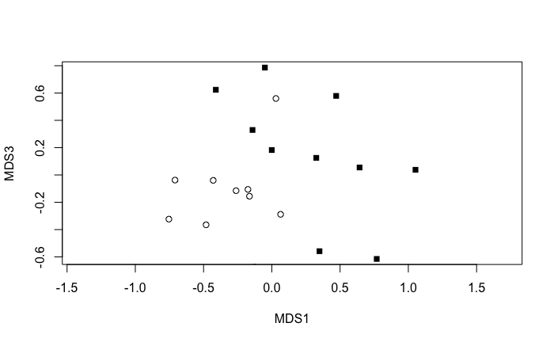

```r
ordiplot(park1s.mds$points,type="n",display="sites",choices=c(1,3))
points(park1s.mds$points,pch=as.numeric(park$symb))
```

**note** that ordihull might be useful to draw boundaries around each group??

### Check homogeneity of dispersions

Check first with file of abundances, then proportional abundances

```r
park1.disp <- betadisper(park1.bc,park$treat)
anova(park1.disp)
```

```
Analysis of Variance Table

Response: Distances
          Df  Sum Sq  Mean Sq F value Pr(>F)
Groups     1 0.01698 0.016977  0.4559 0.5081
Residuals 18 0.67021 0.037234
```

```r
park1s.disp <- betadisper(park1s.bc,park$treat)
anova(park1s.disp)
```

```
Analysis of Variance Table

Response: Distances
          Df   Sum Sq   Mean Sq F value  Pr(>F)
Groups     1 0.022832 0.0228325  3.5176 0.07704 .
Residuals 18 0.116837 0.0064909
---
Signif. codes:  0 ‘***’ 0.001 ‘**’ 0.01 ‘*’ 0.05 ‘.’ 0.1 ‘ ’ 1
```

### Do anosim on abundances and prop. abundances

```r
park1.ano <- anosim(park1.bc, park$treat,permutations=999)
summary(park1.ano)
```

```
Call:
anosim(x = park1.bc, grouping = park$treat, permutations = 999)
Dissimilarity: bray

ANOSIM statistic R: 0.678
      Significance: 0.001

Permutation: free
Number of permutations: 999

Upper quantiles of permutations (null model):
  90%   95% 97.5%   99%
0.111 0.152 0.228 0.358

Dissimilarity ranks between and within classes:
        0%   25%   50%    75% 100%   N
Between  8 95.75 135.5 165.25  190 100
ALAN     1 15.00  36.0 113.00  158  45
no ALAN 10 45.00  64.0  81.00  160  45
```

```r
park1s.ano <- anosim(park1s.bc, park$treat,permutations=999)
summary(park1s.ano)
```

```
Call:
anosim(x = park1s.bc, grouping = park$treat, permutations = 999)
Dissimilarity: bray

ANOSIM statistic R: 0.2989
      Significance: 0.001

Permutation: free
Number of permutations: 999

Upper quantiles of permutations (null model):
   90%    95%  97.5%    99%
0.0884 0.1145 0.1374 0.1649

Dissimilarity ranks between and within classes:
        0%  25% 50%   75% 100%   N
Between  5 72.5 113 151.5  190 100
ALAN     1 25.0  51  77.0  177  45
no ALAN  8 59.0 111 143.5  187  45
```

```r
# do permanova on abundances
park1.ado <- adonis2(park1.bc~treat,data=park,permutations=999)
print(park1.ado)
```

```
Permutation test for adonis under reduced model
Terms added sequentially (first to last)
Permutation: free
Number of permutations: 999

adonis2(formula = park1.bc ~ treat, data = park, permutations = 999)
         Df SumOfSqs      R2      F Pr(>F)
treat     1   1.6916 0.46132 15.415  0.001 ***
Residual 18   1.9753 0.53868
Total    19   3.6669 1.00000
---
Signif. codes:  0 ‘***’ 0.001 ‘**’ 0.01 ‘*’ 0.05 ‘.’ 0.1 ‘ ’ 1
```

```r
# do permanova on prop abundances
park1s.ado <- adonis2(park1s.bc~treat,data=park,permutations=999)
print(park1s.ado)
```

```
Permutation test for adonis under reduced model
Terms added sequentially (first to last)
Permutation: free
Number of permutations: 999

adonis2(formula = park1s.bc ~ treat, data = park, permutations = 999)
         Df SumOfSqs      R2      F Pr(>F)
treat     1   0.7251 0.12406 2.5493  0.001 ***
Residual 18   5.1195 0.87594
Total    19   5.8446 1.00000
---
Signif. codes:  0 ‘***’ 0.001 ‘**’ 0.01 ‘*’ 0.05 ‘.’ 0.1 ‘ ’ 1
```

### mvabund

Run using negative binomial for raw abundances and double standardized abundances from earlier

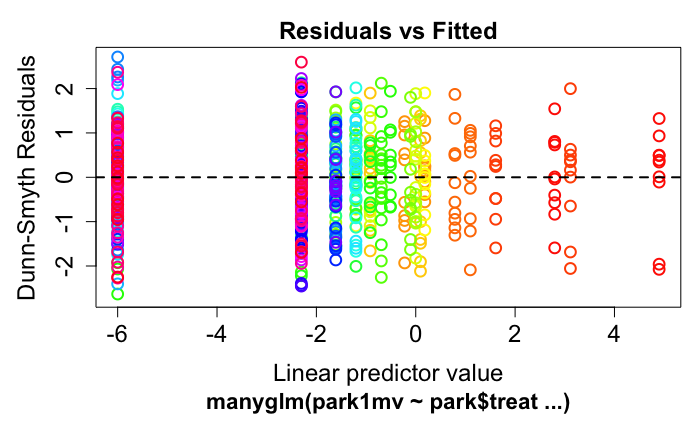

```r
park1mv <- mvabund(park1)
park1mv.mv <- manyglm(park1mv~park$treat,family="negative.binomial")
plot(park1mv.mv)
```

```r
anova(park1mv.mv)
```

```
Time elapsed: 0 hr 0 min 6 sec
Analysis of Deviance Table

Model: park1mv ~ park$treat

Multivariate test:
            Res.Df Df.diff   Dev Pr(>Dev)
(Intercept)     19
park$treat      18       1 106.7    0.001 ***
---
Signif. codes:  0 ‘***’ 0.001 ‘**’ 0.01 ‘*’ 0.05 ‘.’ 0.1 ‘ ’ 1
Arguments:
 Test statistics calculated assuming uncorrelated response (for faster computation)
 P-value calculated using 999 iterations via PIT-trap resampling.
```

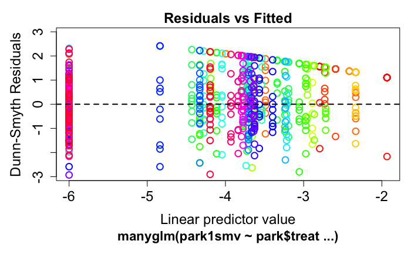

```r
park1smv <- mvabund(park1s)
park1smv.mv <- manyglm(park1smv~park$treat,family="negative.binomial")
plot(park1smv.mv)
```

```r
anova(park1smv.mv)
```

```
Time elapsed: 0 hr 0 min 1 sec
Analysis of Deviance Table

Model: park1smv ~ park$treat

Multivariate test:
            Res.Df Df.diff   Dev Pr(>Dev)
(Intercept)     19
park$treat      18       1 10.32    0.001 ***
---
Signif. codes:  0 ‘***’ 0.001 ‘**’ 0.01 ‘*’ 0.05 ‘.’ 0.1 ‘ ’ 1
Arguments:
 Test statistics calculated assuming uncorrelated response (for faster computation)
 P-value calculated using 999 iterations via PIT-trap resampling.
```

### SIMPER analysis for group differences

Again, abundances then proportional abundances

```r
park1.sim <- simper(park1, park$treat, permutations=1000)
summary(park1.sim)
```

```
Contrast: ALAN_no ALAN

          average        sd     ratio       ava       avb cumsum      p
caen      0.53070   0.20750   2.55780 134.20000  16.40000  0.751 0.0010 ***
chiron    0.08170   0.04078   2.00370  22.50000   5.00000  0.867 0.0040 **
dolich    0.01470   0.01466   1.00550   2.20000   3.00000  0.888 1.0000
cerat     0.00790   0.01279   0.61550   1.00000   0.20000  0.899 0.0519 .
aphid     0.00750   0.00928   0.81220   1.20000   0.30000  0.909 0.0919 .
ephyd     0.00660   0.00852   0.78060   1.10000   0.40000  0.919 0.9940
baet      0.00620   0.00540   1.15350   1.20000   0.80000  0.928 1.0000
chryso    0.00520   0.00625   0.82480   1.00000   0.40000  0.935 1.0000
culicid   0.00450   0.00600   0.74470   0.90000   0.20000  0.941 0.8601
tetrag    0.00440   0.00853   0.51620   0.50000   0.10000  0.948 0.1429
hydro     0.00410   0.00580   0.71390   0.50000   0.30000  0.954 0.9920
tipulid   0.00300   0.00474   0.62510   0.10000   0.40000  0.958 1.0000
muscid    0.00280   0.00628   0.43820   0.60000   0.00000  0.962 0.0010 ***
empid     0.00190   0.00480   0.40060   0.20000   0.00000  0.964 0.0010 ***
formic    0.00190   0.00360   0.52220   0.00000   0.30000  0.967 1.0000
polycen   0.00180   0.00356   0.51820   0.00000   0.30000  0.970 1.0000
sciomyz   0.00180   0.00456   0.39200   0.20000   0.00000  0.972 0.0010 ***
helod     0.00170   0.00277   0.62610   0.30000   0.10000  0.975 0.9940
taban     0.00150   0.00457   0.32730   0.10000   0.00000  0.977 0.0010 ***
cosmop    0.00150   0.00457   0.32730   0.10000   0.00000  0.979 0.0010 ***
coen      0.00140   0.00289   0.49910   0.20000   0.10000  0.981 0.9980
delph     0.00140   0.00324   0.43420   0.30000   0.00000  0.983 0.0010 ***
notonec   0.00130   0.00249   0.53090   0.20000   0.10000  0.985 0.9950
leptoc    0.00110   0.00315   0.36010   0.10000   0.10000  0.986 1.0000
noctuid   0.00110   0.00267   0.42410   0.00000   0.20000  0.988 1.0000
hydroph   0.00100   0.00282   0.34170   0.10000   0.10000  0.989 1.0000
hydropt   0.00090   0.00271   0.34770   0.10000   0.10000  0.991 1.0000
aran      0.00090   0.00271   0.34770   0.10000   0.10000  0.992 1.0000
corix     0.00090   0.00182   0.48520   0.20000   0.00000  0.993 0.0010 ***
limneph   0.00080   0.00167   0.49110   0.20000   0.00000  0.994 0.0010 ***
phryg     0.00070   0.00269   0.26640   0.00000   0.10000  0.995 1.0000
cicad     0.00070   0.00269   0.26640   0.00000   0.10000  0.996 1.0000
agrom     0.00070   0.00251   0.27120   0.00000   0.10000  0.997 1.0000
mymar     0.00070   0.00251   0.27120   0.00000   0.10000  0.998 1.0000
halip     0.00060   0.00222   0.27940   0.00000   0.10000  0.999 1.0000
acrid     0.00060   0.00175   0.33090   0.10000   0.00000  1.000 0.0010 ***
---
Signif. codes:  0 ‘***’ 0.001 ‘**’ 0.01 ‘*’ 0.05 ‘.’ 0.1 ‘ ’ 1
Permutation: free
Number of permutations: 1000
```

```r
park1s.sim <- simper(park1s, park$treat, permutations=10000)
summary(park1s.sim)
```

```
Contrast: ALAN_no ALAN

        average      sd   ratio     ava     avb cumsum      p
dolich  0.05568 0.05036 1.10550 0.06115 0.14459  0.069 0.0451 *
tipulid 0.05435 0.06561 0.82830 0.03055 0.09695  0.137 0.1938
formic  0.04838 0.07860 0.61550 0.00000 0.09676  0.197 0.0001 ***
caen    0.03616 0.01885 1.91820 0.08926 0.01838  0.242 0.0005 ***
baet    0.03615 0.02236 1.61730 0.07487 0.06517  0.287 0.2027
helod   0.03376 0.04641 0.72760 0.05221 0.02576  0.329 0.3398
polycen 0.03299 0.05306 0.62170 0.00000 0.06598  0.370 0.0001 ***
cerat   0.03128 0.03457 0.90500 0.05570 0.02632  0.409 0.3629
hydroph 0.03085 0.07579 0.40700 0.01319 0.05115  0.448 0.4751
coen    0.02717 0.04624 0.58750 0.03912 0.02293  0.481 0.4763
ephyd   0.02609 0.03149 0.82850 0.04708 0.01636  0.514 0.3082
aphid   0.02539 0.02526 1.00530 0.05701 0.01516  0.545 0.0281 *
chiron  0.02316 0.01568 1.47660 0.06636 0.02707  0.574 0.0099 **
tetrag  0.02269 0.02822 0.80400 0.04104 0.01191  0.602 0.1924
chryso  0.02090 0.01881 1.11120 0.03550 0.02412  0.628 0.3283
empid   0.02003 0.04668 0.42900 0.04005 0.00000  0.653 0.0001 ***
noctuid 0.01971 0.04172 0.47230 0.00000 0.03941  0.678 0.0001 ***
notonec 0.01917 0.03336 0.57470 0.02914 0.01387  0.702 0.4788
leptoc  0.01892 0.04045 0.46780 0.01752 0.02383  0.725 0.4649
hydro   0.01827 0.02060 0.88690 0.02471 0.02474  0.748 0.7008
hydropt 0.01755 0.03856 0.45520 0.01319 0.02456  0.770 0.4700
aran    0.01755 0.03856 0.45520 0.01319 0.02456  0.792 0.4700
halip   0.01674 0.05049 0.33170 0.00000 0.03349  0.812 0.0001 ***
culicid 0.01439 0.01842 0.78120 0.02561 0.00793  0.830 0.1964
sciomyz 0.01412 0.02846 0.49610 0.02824 0.00000  0.848 0.0001 ***
phryg   0.01328 0.04004 0.33170 0.00000 0.02656  0.865 0.0001 ***
cicad   0.01328 0.04004 0.33170 0.00000 0.02656  0.881 0.0001 ***
corix   0.01316 0.02770 0.47510 0.02632 0.00000  0.897 0.0001 ***
limneph 0.01259 0.02624 0.47980 0.02518 0.00000  0.913 0.0001 ***
agrom   0.01147 0.03457 0.33170 0.00000 0.02293  0.927 0.0001 ***
mymar   0.01147 0.03457 0.33170 0.00000 0.02293  0.942 0.0001 ***
muscid  0.01124 0.02506 0.44870 0.02249 0.00000  0.956 0.0001 ***
delph   0.01078 0.02556 0.42180 0.02157 0.00000  0.969 0.0001 ***
acrid   0.00982 0.02960 0.33170 0.01964 0.00000  0.981 0.0001 ***
taban   0.00753 0.02270 0.33170 0.01505 0.00000  0.991 0.0001 ***
cosmop  0.00753 0.02270 0.33170 0.01505 0.00000  1.000 0.0001 ***
---
Signif. codes:  0 ‘***’ 0.001 ‘**’ 0.01 ‘*’ 0.05 ‘.’ 0.1 ‘ ’ 1
Permutation: free
Number of permutations: 10000
```

### Generate graphs

**Note:** graphs may not run at the moment because of a problem in vegan 2.6.2 relating to the scores function when dealing with mds objects. Expecting a fix soon (as of 7 June 2022). Problem did not exist prior to this version of vegan

```r
br=c("ALAN","no ALAN")
la=c("ALAN", "No ALAN")
a<-as.data.frame(scores(park1.mds))
a<-cbind(park[c(1:2)],a)   #Add mesocosms & treatments from original data file
p1<-ggplot(data=a, aes(x=NMDS1, y=NMDS2, shape=treat) )+
  geom_point()+
  labs(y="MDS2", x="MDS1", title="Raw")+
  scale_shape_manual(values=sym2,
                     name="Treat",
                     breaks=br,
                     labels=la,
                     guide =
                         guide_legend(label.theme = element_text(size=6),
                                      title=NULL)
                     )+
  theme_qk()
as<-as.data.frame(scores(park1s.mds))
as<-cbind(park[c(1:2)],as)   #Add mesocosms & treatments from original data file

p2<-ggplot(data=as, aes(x=NMDS1, y=NMDS2, shape=treat) )+
  geom_point()+
  labs(y=NULL, x="MDS1", title="Standardized")+
  scale_shape_manual(values=sym2,
                     name="Treat",
                     breaks=br,
                     labels=la,
                     guide =
                         guide_legend(label.theme = element_text(size=6),
                                    title=NULL)
                     )+
  theme_qk()

p4<-p1+p2+plot_layout(guides='collect')&theme(axis.text=element_blank())
```

|  | t | l | b | r |
| --- | --- | --- | --- | --- |
| 1: | 1 | 1 | 1 | 1 |
| 2: | 1 | 2 | 1 | 2 |

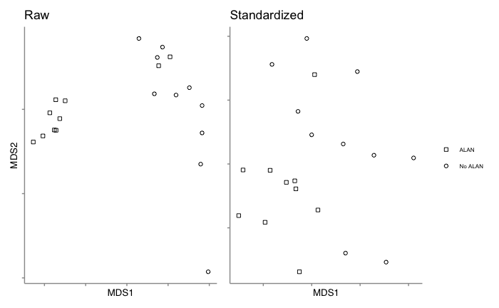

```r
p4
```

```r
# with ellipses
p1a<-p1+stat_ellipse(geom="polygon", alpha= 0.2)
p2a<-p2+stat_ellipse(geom="polygon", alpha= 0.2)
p4a<-p1a+p2a+plot_layout(guides='collect')
```

|  | t | l | b | r |
| --- | --- | --- | --- | --- |
| 1: | 1 | 1 | 1 | 1 |
| 2: | 1 | 2 | 1 | 2 |

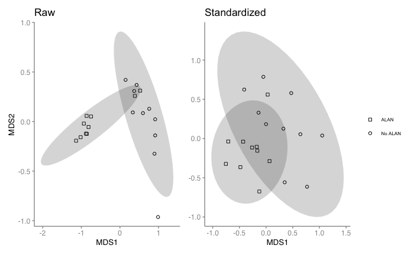

```r
p4a
```

Color versions

```r
p1<-ggplot(data=a, aes(x=NMDS1, y=NMDS2, color=treat, fill=treat) )+
  geom_point()+
  labs(y="MDS2", x="MDS1", title="Raw")+
  scale_color_uchicago(name="Treat",
                     breaks=br,
                     labels=la,
                     guide =
                         guide_legend(label.theme = element_text(size=6),
                                      title=NULL)
                     )+
  scale_fill_uchicago(name="Treat",
                     breaks=br,
                     labels=la,
                     guide =
                         guide_legend(label.theme = element_text(size=6),
                                    title=NULL))+
  theme_qk()

p2<-ggplot(data=as, aes(x=NMDS1, y=NMDS2, color=treat, fill=treat) )+
  geom_point()+
  labs(y=NULL, x="MDS1", title="Standardized")+
  scale_color_uchicago(
                     name="Treat",
                     breaks=br,
                     labels=la,
                     guide =
                         guide_legend(label.theme = element_text(size=6),
                                    title=NULL)
                     )+
  scale_fill_uchicago(name="Treat",
                     breaks=br,
                     labels=la,
                     guide =
                         guide_legend(label.theme = element_text(size=6),
                                    title=NULL))+
  theme_qk()

p4<-p1+p2+plot_layout(guides='collect')&theme(axis.text=element_blank())
```

|  | t | l | b | r |
| --- | --- | --- | --- | --- |
| 1: | 1 | 1 | 1 | 1 |
| 2: | 1 | 2 | 1 | 2 |

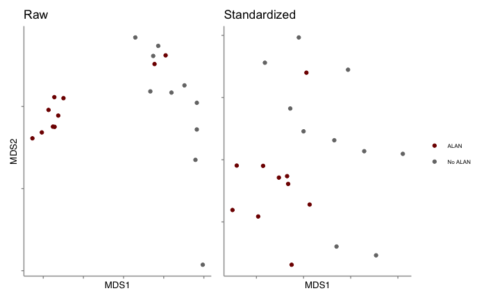

```r
p4
```

```r
# with ellipses
p1a<-p1+stat_ellipse(geom="polygon", alpha= 0.2)
p2a<-p2+stat_ellipse(geom="polygon", alpha= 0.2)
p4a<-p1a+p2a+plot_layout(guides='collect')&theme(axis.text=element_blank())
```

|  | t | l | b | r |
| --- | --- | --- | --- | --- |
| 1: | 1 | 1 | 1 | 1 |
| 2: | 1 | 2 | 1 | 2 |

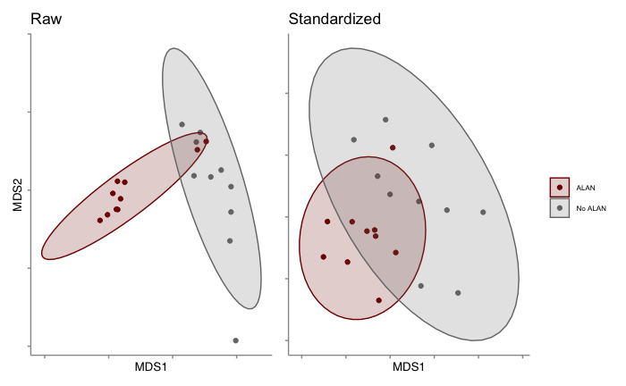

```r
p4a
```